# GTEx Threshold Analysis

#### Note: This notebook is still being reviewed - review process performed up to binary expression matrix section

Threshold analysis was an initial approach to identify NPTR genes but was not used as it was found to be a naive approach.

```r
# Setup for packages and data files
library(ggplot2)
library(tidyverse)
library(ggrepel) # labels on ggplot
library(ggforce) # facet wrap paginate
# library(knitr)
library(matrixStats) # for rowMedians
# library(DT) # datatable
library(reldist) # Gini Coefficient
library(reshape2) # for melt

# Load condensed gtex median by tpm
# sub-tissues have been condensed to single tissue using maximum value
# See gtex_tpm_condensed.csv for more details
gtex_tpm_condensed <- read_csv("../data/processed/gtex_tpm_condensed.csv")
```

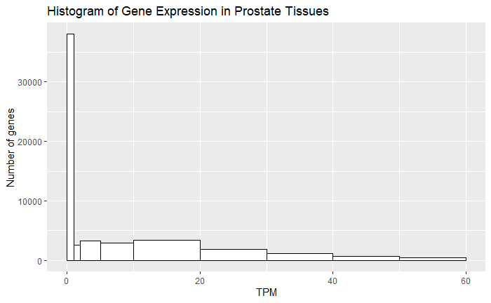

```r
ggplot(melt((gtex_tpm_condensed$Prostate)),aes(x = value)) +
  geom_histogram(breaks = c(0,1,2, 5, 10, 20, 30, 40, 50, 60), color = 'black', fill = 'white') +
  coord_cartesian(xlim=c(0, 60)) +
  labs(title = 'Histogram of Gene Expression in Prostate Tissues',
       x = 'TPM',
       y = 'Number of genes')
```

# Threshold Matrix

We want a Y/N matrix of whether a gene is expressed in a tissue or not. From this matrix we can determine if a gene is:

- a prostate gene or a non prostate gene
  - if it is a prostate gene, is it:
    - prostate specific or
    - global
  - if it is a non-prostate gene, is it:
    - specific to a certain other tissue or
    - global

*N.B. Mitochondrial genes (’MT_**’) and ribosomal genes (RP**_) may not be useful - might be a good idea to remove them as well as non-protein coding genes (anything with a period.)*

## Binary Matrix

The expression data was changed to a binary matrix indicating whether or not a gene is expressed in a certain tissue. - Change value to 1 if the expression > 1 TPM - Change value to 0 if the expression < 1 TPM

We now have a binary gene expression matrix. Using this threshold, We can see that 18196 genes in this matrix are expressed in prostate tissue.

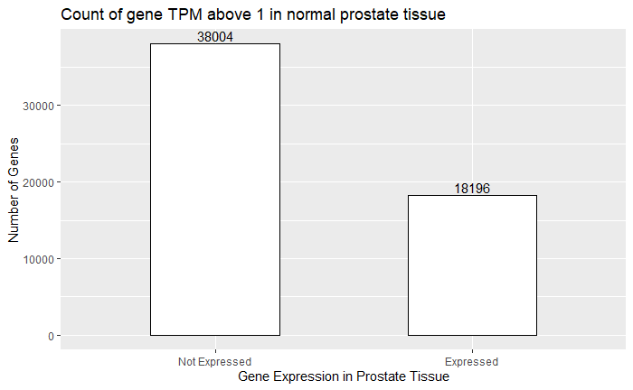

```r
# frequency plot
# 18196 genes expressed in prostate
ggplot(data = threshold_mat, aes(x = factor(Prostate))) +
  geom_bar(color = 'black', fill = 'white', width = 0.5) +
  geom_text(stat='count', aes(label = ..count..), vjust = -0.3) +
    labs(title = 'Count of gene TPM above 1 in normal prostate tissue',
        x = 'Gene Expression in Prostate Tissue',
        y = 'Number of Genes') +
  scale_x_discrete(labels=c("0" = "Not Expressed", "1" = "Expressed"))
```

Now, total number of tissues that were expressed in each gene were calculated before determining the ratio of tissues that with gene expression.

N.B. 12,115 genes are not expressed (0 TPM) in any tissue

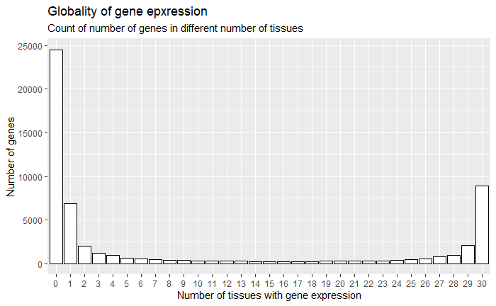

```r
# Calculate sums of trues, falses and proportion of trues
threshold_mat$Expressed <- rowSums(threshold_mat[c(3:32)] == 1)
threshold_mat$Not_Expressed <- 30 - threshold_mat$Expressed
threshold_mat$Expressed_ratio <- threshold_mat$Expressed /(threshold_mat$Expressed + threshold_mat$Not_Expressed)

ggplot(data = threshold_mat, aes(x = factor(Expressed))) +
  geom_bar(color = 'black', fill = 'white') +
  labs(title = 'Globality of gene epxression',
       subtitle = 'Count of number of genes in different number of tissues',
       x = 'Number of tissues with gene expression',
       y = 'Number of genes')
```

Notes:

- 24513 genes (44%) are not expressed in any tissue
- 6881 genes (12%) are expressed in only *one* tissue.
- 8916 genes (16%) are expressed in *all* tissues.

# Prostate Genes

A new matrix was created such that it contained only the genes that are expressed in the prostate tissue.

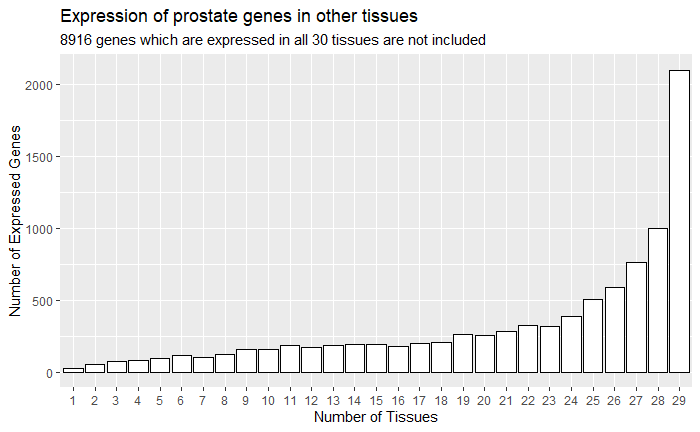

```r
# Variable to hold dataframe of genes expressed in normal prostate tissue
prostate_expr <- filter(threshold_mat, Prostate == 1)

# Genes NOT expressed in normal prostate tissue
prostate_nonexpr <- filter(threshold_mat, Prostate == 0)

ggplot(data = filter(prostate_expr, Expressed < 30)) +
  geom_bar(mapping = aes(factor(x = Expressed)),
                 color = 'black',
                 fill = 'white') +
  labs(title = 'Expression of prostate genes in other tissues',
       subtitle = '8916 genes which are expressed in all 30 tissues are not included',
       x = 'Number of Tissues',
       y = 'Number of Expressed Genes')
```

- 18196 genes are expressed in prostate tissue. Of these:
  - 8916 of these genes are expressed in *all* tissues
  - 26 of these genes are expressed in *only* prostate tissue.
  - 154 of these genes are expressed in less than or eqal to *10%* of all tissues - defined as prostate-specific.

### Prostate Only Genes

```r
threshold_mat %>%
  filter(Prostate == 1 & Expressed == 1) %>% # filter rows to select the genes expressed only in prostate tissue
  select(Name) %>% # select corresponding gene names
  inner_join(gtex_tpm_condensed, by = "Name") %>% # join maximum values of these genes
  filter(Prostate > 1) %>% # filter out any non-expressed rows in case of duplicates
  select(Description, Prostate) %>%
  datatable(width = 300)
```

[output not shown]

Notes:

- 11 non-coding RNA RP genes
- STEAP2 - increased expression associated with prostate cancer progression
- PCAT4 - prostate cancer associated transcript 4
- SNORA42 - small nucleolar RNA that guide the sites of modification of uridines to pseudouridines, prognostic biomarker in colorectal cancers

### Prostate Specific Genes

```r
prostate_expr_specific <- filter(prostate_expr, Expressed_ratio <= 0.1)

threshold_mat %>%
  filter(Prostate == 1 & Expressed_ratio <= 0.1) %>% # filter rows to select the genes expressed in prostate tissue and less than                                                      #  10% of other tissues
  select(Name, Expressed) %>% # select corresponding gene names
  inner_join(gtex_tpm_condensed, by = c("Name")) %>% # join maximum values of these genes
  filter(Prostate > 1) %>% # filter out any non-expressed rows in case of duplicates
  datatable()
```

[output not shown]

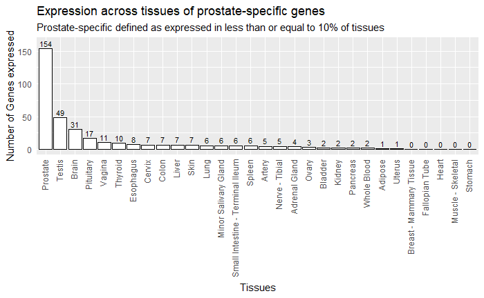

```r
prostate_expr_specific.totals <- data.frame(value=apply(prostate_expr_specific[3:32],2,sum))
# geom_col used instead of geom_col because it uses stat_identity by default
ggplot(data = prostate_expr_specific.totals,
       aes(x = factor(reorder(rownames(prostate_expr_specific.totals), -value)),
           y = value,
           label = value)) +
  geom_col(colour = 'black',
           fill = 'white') +
  labs(title = 'Expression across tissues of prostate-specific genes',
       subtitle = 'Prostate-specific defined as expressed in less than or equal to 10% of tissues',
       x = 'Tissues',
       y = 'Number of Genes expressed') +
  theme(axis.text.x = element_text(angle = 90,
                                   hjust = 1,
                                   vjust = 0.3),
        axis.ticks = element_blank()) +
  geom_text(size = 3,
            nudge_y = 8)
```

```r
# COMMENTS

prostate_expr_specific %>%
  filter(Liver == 1) %>%
  select(Name) %>%
  inner_join(gtex_tpm_condensed, by = c("Name")) %>% # join TPM data of these genes
  select(Description, Liver, Prostate) %>%
  datatable(width = 400)
```

[output not shown]

```r
prostate_expr_specific %>%
  filter(Brain == 1) %>%
  select(Name) %>%
  inner_join(gtex_tpm_condensed, by = c("Name")) %>% # join TPM data of these genes
  select(Description, Brain, Prostate) %>%
  datatable(width = 400)
```

[output not shown]

### Global Prostate Genes

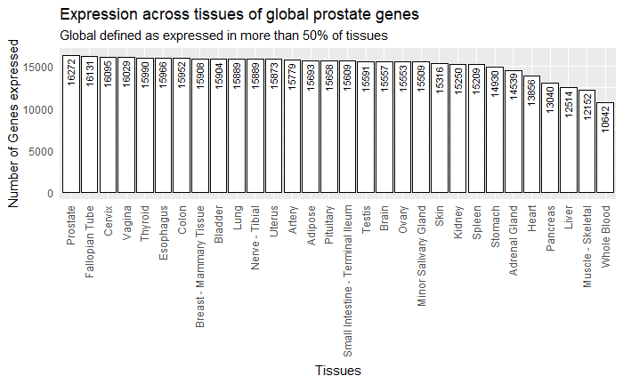

```r
prostate_expr_global <- filter(prostate_expr, Expressed_ratio > 0.5)

prostate_expr_global.totals <- data.frame(value=apply(prostate_expr_global[3:32],2,sum))

# geom_col used instead of geom_col because it uses stat_identity by default
ggplot(data = prostate_expr_global.totals,
       aes(x = factor(reorder(rownames(prostate_expr_global.totals), -value)),
           y = value,
           label = value)) +
  geom_col( colour = 'black', fill = 'white') +
  labs(title = 'Expression across tissues of global prostate genes',
       subtitle = 'Global defined as expressed in more than 50% of tissues',
       x = 'Tissues',
       y = 'Number of Genes expressed') +
  theme(axis.text.x = element_text(angle = 90,
                                   hjust = 1,
                                   vjust = 0.4),
        axis.ticks = element_blank()) +
  geom_text(size = 3,
            nudge_y = -2000,
            nudge_x = -0.05,
            angle = 90)
```

# Non-prostate genes

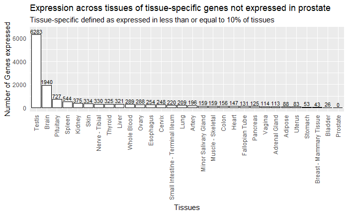

```r
non_prostate <- filter(threshold_mat, Prostate == 0 & Expressed > 0)

non_prostate_tissue.specific <- filter(non_prostate, Expressed_ratio > 0 & Expressed_ratio <= 0.1)

non_prostate_tissue.specific.totals <- data.frame(value=apply(non_prostate_tissue.specific[3:32],2,sum))

ggplot(data = non_prostate_tissue.specific.totals,
       aes(x = factor(reorder(rownames(non_prostate_tissue.specific.totals), -value)),
           y = value,
           label = value)) +
  geom_col(colour = 'black',
            fill = 'white') +
  labs(title = 'Expression across tissues of tissue-specific genes not expressed in prostate',
       subtitle = 'Tissue-specific defined as expressed in less than or equal to 10% of tissues',
       x = 'Tissues',
       y = 'Number of Genes expressed') +
  theme(axis.text.x = element_text(angle = 90,
                                   hjust = 1,
                                   vjust = 0.4),
        axis.ticks = element_blank()) +
  geom_text(size = 2.8,
            nudge_y = 300)
```

# Genes of Interest

## KLK Genes

Notes:

- KLKP1 is prostate specific - expressed in the testis and the prostate
- No other KLK genes are prostate only or prostate specific

```r
KLK.all.max <- filter(gtex_tpm_condensed, startsWith(Description, 'KLK'))

KLK.all.max %>%
  select(Name, Description, Prostate) %>%
  inner_join(threshold_mat[, c('Name', 'Expressed_ratio')], by = "Name") %>%
  datatable()
```

[output not shown]

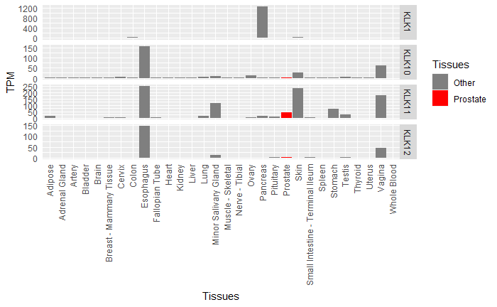

```r
KLK.all.max[2:32] %>%
  gather(Tissues, TPM, -Description)  %>%
  ggplot(aes(Tissues, TPM, fill = ifelse(Tissues == 'Prostate', 'Prostate', 'Other'))) +
      geom_col() +
      facet_grid_paginate(Description ~ .,
                          nrow = 4,
                          ncol = 1,
                          page = 1,
                          scales = 'free') +
      scale_fill_manual(name = 'Tissues',
                        values = c('grey50', 'red')) +
      theme(axis.text.x = element_text(angle = 90,
                                     hjust = 1,
                                     vjust = 0.4),
          axis.ticks = element_blank())
```

```r
KLK.all.max[2:32] %>%
  gather(Tissues, TPM, -Description)  %>%
  ggplot(aes(Tissues, TPM, fill = ifelse(Tissues == 'Prostate', 'Prostate', 'Other'))) +
      geom_col() +
      facet_grid_paginate(Description ~ .,
                          nrow = 4,
                          ncol = 1,
                          page = 2,
                          scales = 'free') +
      scale_fill_manual(name = 'Tissues',
                        values = c('grey50', 'red')) +
      theme(axis.text.x = element_text(angle = 90,
                                     hjust = 1,
                                     vjust = 0.4),
          axis.ticks = element_blank())
```

[output not shown]

```r
KLK.all.max[2:32] %>%
  gather(Tissues, TPM, -Description)  %>%
  ggplot(aes(Tissues, TPM, fill = ifelse(Tissues == 'Prostate', 'Prostate', 'Other'))) +
      geom_col() +
      facet_grid_paginate(Description ~ .,
                          nrow = 4,
                          ncol = 1,
                          page = 3,
                          scales = 'free') +
      scale_fill_manual(name = 'Tissues',
                        values = c('grey50', 'red')) +
      theme(axis.text.x = element_text(angle = 90,
                                     hjust = 1,
                                     vjust = 0.4),
          axis.ticks = element_blank())
```

[output not shown]

```r
KLK.all.max[2:32] %>%
  gather(Tissues, TPM, -Description)  %>%
  ggplot(aes(Tissues, TPM, fill = ifelse(Tissues == 'Prostate', 'Prostate', 'Other'))) +
      geom_col() +
      facet_grid_paginate(Description ~ .,
                          nrow = 4,
                          ncol = 1,
                          page = 4,
                          scales = 'free') +
      scale_fill_manual(name = 'Tissues',
                        values = c('grey50', 'red')) +
      theme(axis.text.x = element_text(angle = 90,
                                     hjust = 1,
                                     vjust = 0.4),
          axis.ticks = element_blank())
```

[output not shown]

```r
KLK.all.max[2:32] %>%
  gather(Tissues, TPM, -Description)  %>%
  ggplot(aes(Tissues, TPM, fill = ifelse(Tissues == 'Prostate', 'Prostate', 'Other'))) +
      geom_col() +
      facet_grid_paginate(Description ~ .,
                          nrow = 1,
                          ncol = 1,
                          page = 17,
                          scales = 'free') +
      scale_fill_manual(name = 'Tissues',
                        values = c('grey50', 'red')) +
      theme(axis.text.x = element_text(angle = 90,
                                     hjust = 1,
                                     vjust = 0.4),
          axis.ticks = element_blank())
```

[output not shown]

## PSMA Protein

### FOLH1 Gene

These two genes are not prostate specific. FOLH1 is expressed in 14 tissues, FOLH1B is expressed in 2 (kidney and liver)

```r
filter(gtex_tpm_condensed, startsWith(Description, "FOLH1"))[2:32] %>%
  gather(Tissues, TPM, -Description)  %>%
  ggplot(aes(Tissues, TPM, fill = ifelse(Tissues == 'Prostate', 'Prostate', 'Other'))) +
      geom_col() +
      facet_grid_paginate(Description ~ .,
                          nrow = 2,
                          ncol = 1,
                          page = 1,
                          scales = 'free') +
      scale_fill_manual(name = 'Tissues',
                        values = c('grey50', 'red')) +
      theme(axis.text.x = element_text(angle = 90,
                                     hjust = 1,
                                     vjust = 0.4),
          axis.ticks = element_blank())
```

[output not shown]

## AMACR Gene

Expressed in all 30 tissues.

```r
filter(gtex_tpm_condensed, startsWith(Description, "AMA"))[2:32] %>%
  gather(Tissues, TPM, -Description)  %>%
  ggplot(aes(Tissues, TPM, fill = ifelse(Tissues == 'Prostate', 'Prostate', 'Other'))) +
      geom_col() +
      facet_grid_paginate(Description ~ .,
                          nrow = 1,
                          ncol = 1,
                          page = 1,
                          scales = 'free') +
      scale_fill_manual(name = 'Tissues',
                        values = c('grey50', 'red')) +
      theme(axis.text.x = element_text(angle = 90,
                                     hjust = 1,
                                     vjust = 0.4),
          axis.ticks = element_blank())
```

[output not shown]

## SLCO1B3

Expressed in the Liver, Nerve - Tibial, Testis. Not expressed in the prostate.

```r
filter(gtex_tpm_condensed, startsWith(Description, "SLCO1B3"))[2:32] %>%
  gather(Tissues, TPM, -Description)  %>%
  ggplot(aes(Tissues, TPM, fill = ifelse(Tissues == 'Prostate', 'Prostate', 'Other'))) +
      geom_col() +
      facet_grid_paginate(Description ~ .,
                          nrow = 1,
                          ncol = 1,
                          page = 1,
                          scales = 'free') +
      scale_fill_manual(name = 'Tissues',
                        values = c('grey50', 'red')) +
      theme(axis.text.x = element_text(angle = 90,
                                     hjust = 1,
                                     vjust = 0.4),
          axis.ticks = element_blank())
```

[output not shown]

```r
filter(gtex_tpm_condensed, startsWith(Description, "SLCO1B3"))[2:32] %>%
  pivot_longer(., names_to = "Tissues",cols = 2:31) %>%
  .$Tissues = factor(.)


filter(x, startsWith(Description, "SLCO1B3"))[2:32] %>%
  gather(Tissues, TPM, -Description)  %>%
  ggplot(aes(Tissues, TPM, fill = ifelse(Tissues == 'Prostate', 'Prostate', 'Other'))) +
      geom_col() +
      facet_grid_paginate(Description ~ .,
                          nrow = 1,
                          ncol = 1,
                          page = 1,
                          scales = 'free') +
      scale_fill_manual(name = 'Tissues',
                        values = c('grey50', 'red')) +
      theme(axis.text.x = element_text(angle = 90,
                                     hjust = 1,
                                     vjust = 0.4),
          axis.ticks = element_blank())
```

## Various Genes

```r
filter(gtex_tpm_condensed, startsWith(Description, "SLCO1B3"))[2:32] %>%
  gather(Tissues, TPM, -Description)  %>%
  ggplot(aes(Tissues, TPM, fill = ifelse(Tissues == 'Prostate', 'Prostate', 'Other'))) +
      geom_col() +
      facet_grid_paginate(Description ~ .,
                          nrow = 1,
                          ncol = 1,
                          page = 1,
                          scales = 'free') +
      scale_fill_manual(name = 'Tissues',
                        values = c('grey50', 'red')) +
      theme(axis.text.x = element_text(angle = 90,
                                     hjust = 1,
                                     vjust = 0.4),
          axis.ticks = element_blank())
```

```r
# Collection of genes of interest
filter(gtex_tpm_condensed, Description == 'KLK3' | Description == 'AMACR' |
                        Description == 'SLCO1B3' | Description == 'STEAP2-AS1')[2:32] %>%
  gather(Tissues, TPM, -Description) %>%
    ggplot(aes(Tissues, TPM, fill = ifelse(Tissues == 'Prostate', 'Prostate', 'Other'))) +
      geom_col() +
      facet_grid_paginate(Description ~ .,
                          nrow = 4,
                          ncol = 1,
                          page = 1,
                          scales = 'free') +
      scale_fill_manual(name = 'Tissues',
                        values = c('grey50', 'red')) +
      theme(axis.text.x = element_text(angle = 90,
                                     hjust = 1,
                                     vjust = 0.4),
          axis.ticks = element_blank())
```

[output not shown]